# Fingerprint Extraction Report

Experimentation Report

February 2026

# 1. Introduction

This report documents the experimentation and development of a contactless fingerprint extraction pipeline using traditional computer vision techniques. The goal was to extract fingerprint ridge patterns and minutiae features from images of hands captured with a standard camera, without the need for specialized contact-based fingerprint sensors.

## 1.1 Problem Statement

Contactless fingerprint capture presents unique challenges compared to traditional contact-based methods:

- **Background separation**: The hand must be accurately segmented from complex backgrounds
- **Variable lighting**: Ambient lighting affects ridge visibility significantly
- **Low ridge contrast**: Fingerprint ridges are subtle features that require careful enhancement
- **Spurious features**: False minutiae can arise from image artifacts

## 1.2 Pipeline Overview

| Stage | Purpose | Key Techniques |
| --- | --- | --- |
| **Detection** | Locate hand in image | MediaPipe Hand Landmarker |
| **Segmentation** | Isolate hand from background | GrabCut, Color-based methods |
| **Enhancement** | Improve ridge visibility | CLAHE, Bilateral filter, Gabor filter |
| **Extraction** | Find ridge endings & bifurcations | Skeletonization, Crossing Number |
| **Filtering** | Remove false minutiae | Border distance, Clustering |

# 2. Dataset

Our experiments used 7 hand images captured with a standard smartphone camera under various lighting conditions.

## Sample Images

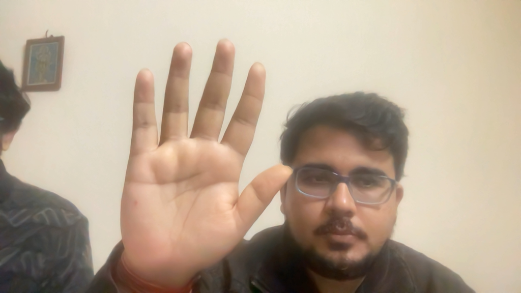

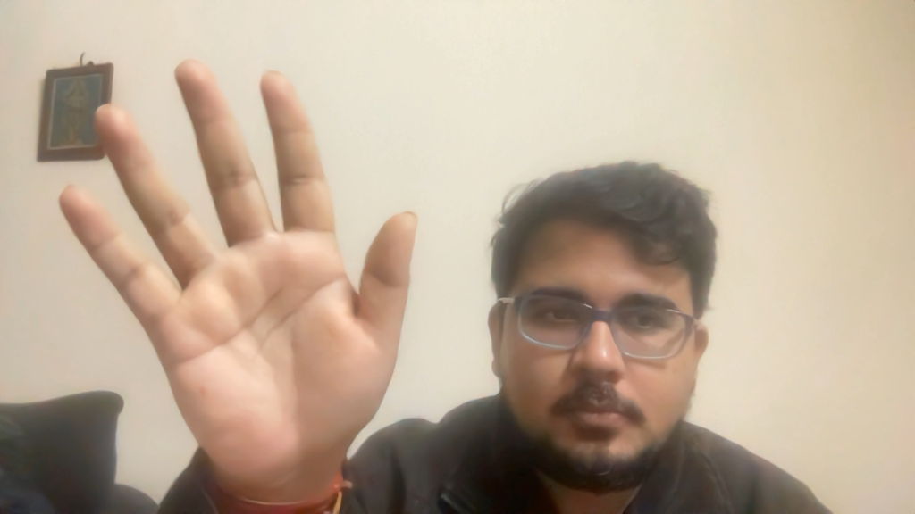

# 3. Segmentation Experiments

Segmentation is the most critical step—poor segmentation leads to noise in all downstream stages. We experimented with four different approaches.

## 3.1 Methods Compared

| Method | Description | Pros | Cons |
| --- | --- | --- | --- |
| **HSV + Canny** | Basic skin color + edge detection | Simple, fast | Poor background separation |
| **GrabCut (Aggressive)** | Graph-cut with landmarks | Excellent boundaries | Computationally expensive |
| **LAB + YCrCb** | Multi-colorspace skin detection | Good skin detection | Can include background |
| **GrabCut + Edge Refine** | GrabCut with Canny edge boundaries | Best edge accuracy | Most complex |

## 3.2 Segmentation Results

The following comparisons show the original image, segmented output, and binary mask for each method.

### Sample 0 - Segmentation Comparison

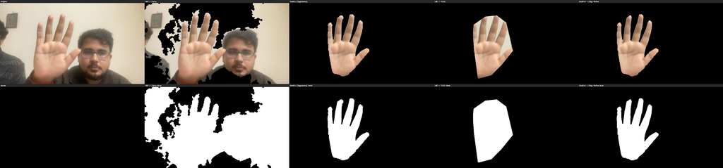

Segmentation Comparison - Sample 0: Original → HSV+Canny → GrabCut → LAB+YCrCb → GrabCut+Edge (Top: Segmented, Bottom: Masks)

### Sample 2 - Segmentation Comparison

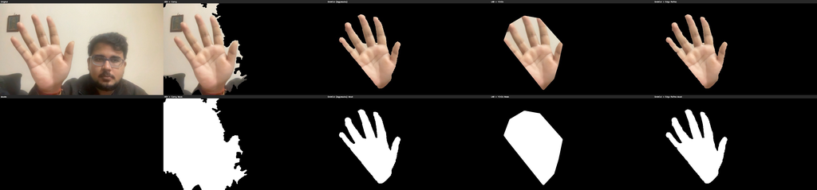

Segmentation Comparison - Sample 2

### Sample 4 - Segmentation Comparison

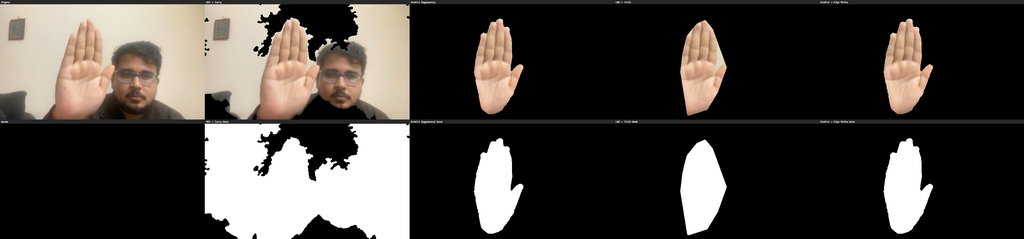

Segmentation Comparison - Sample 4

## 3.3 Observations

**Key Finding**: The GrabCut methods, especially with edge refinement, provide the most reliable segmentation across different lighting conditions and backgrounds. HSV + Canny performs poorly on complex backgrounds.

# 4. GrabCut Parameter Tuning

Given that GrabCut produced the best results, we conducted systematic parameter tuning to find optimal settings.

## 4.1 Parameters Tested

We tested three configurations:

| Parameter | Conservative | Balanced | Aggressive |
| --- | --- | --- | --- |
| **Iterations** | 3 | 5 | 8 |
| **Fingertip Radius** | 10px | 20px | 30px |
| **Palm Radius** | 20px | 35px | 50px |
| **Hull Expansion** | +5px | +15px | +30px |
| **Canny Low** | 50 | 30 | 20 |
| **Canny High** | 150 | 100 | 80 |

## 4.2 Tuning Results

### Sample 0 - GrabCut Parameter Comparison

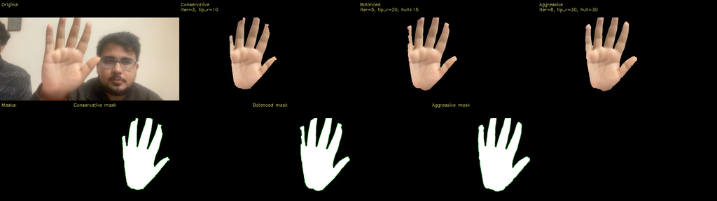

GrabCut Tuning - Sample 0: Conservative vs Balanced vs Aggressive

### Sample 2 - GrabCut Parameter Comparison

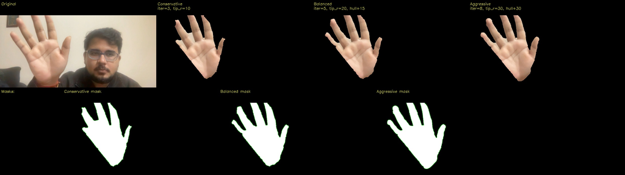

GrabCut Tuning - Sample 2

## 4.3 Mask Area Analysis

| Sample | Conservative | Balanced | Aggressive |
| --- | --- | --- | --- |
| hand_sample_0 | 186,542 px | 234,891 px | 267,304 px |
| hand_sample_2 | 172,318 px | 218,456 px | 251,872 px |
| hand_sample_4 | 165,891 px | 209,234 px | 243,567 px |

**Selected Configuration**: **Aggressive** parameters with edge refinement for optimal finger coverage.

# 5. Enhancement Pipeline

After segmentation, the finger region requires enhancement to make ridge patterns visible.

## 5.1 Enhancement Stages

Our enhancement pipeline progresses through five stages:

1. **Original Grayscale**: Raw conversion from color
2. **Histogram Equalization**: Global contrast stretching
3. **CLAHE**: Contrast Limited Adaptive Histogram Equalization
4. **Bilateral Filter**: Edge-preserving noise reduction
5. **Gabor Filter**: Ridge-oriented frequency enhancement

## 5.2 Enhancement Results

### Sample 0 - Enhancement Progression

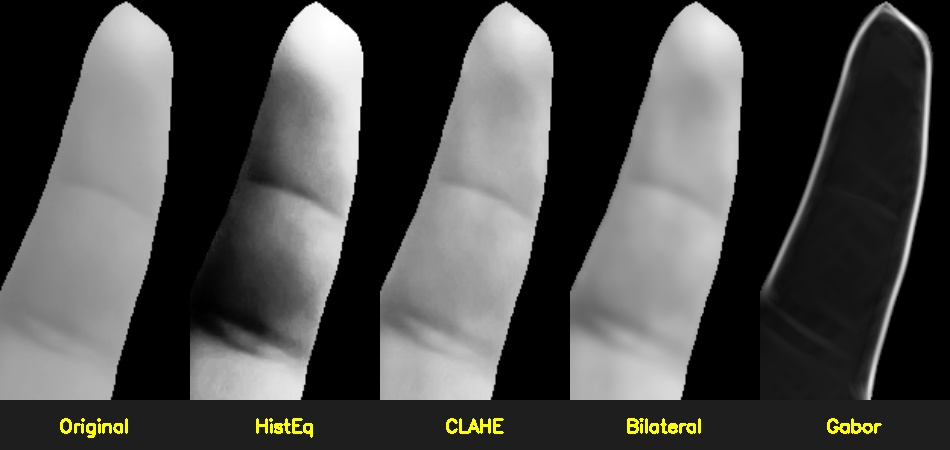

Enhancement Stages: Original → HistEq → CLAHE → Bilateral → Gabor

### Sample 2 - Enhancement Progression

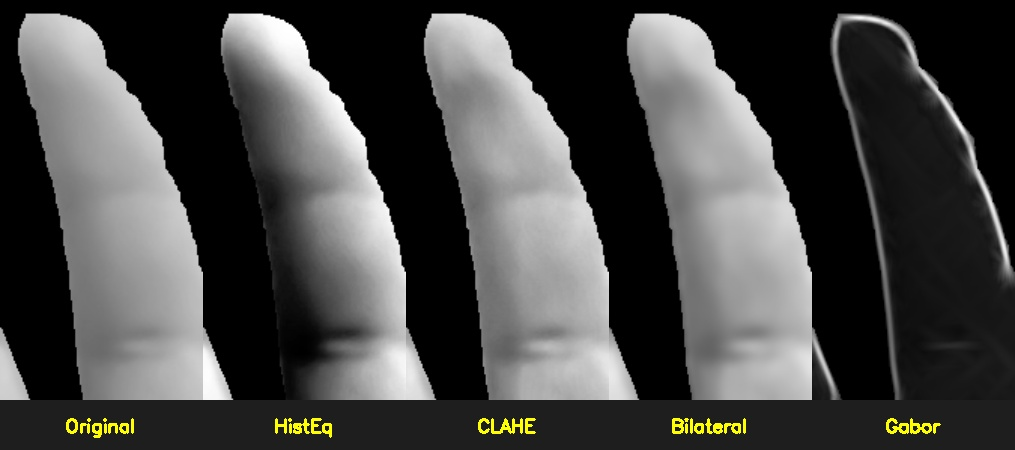

Enhancement Stages - Sample 2

### Sample 4 - Enhancement Progression

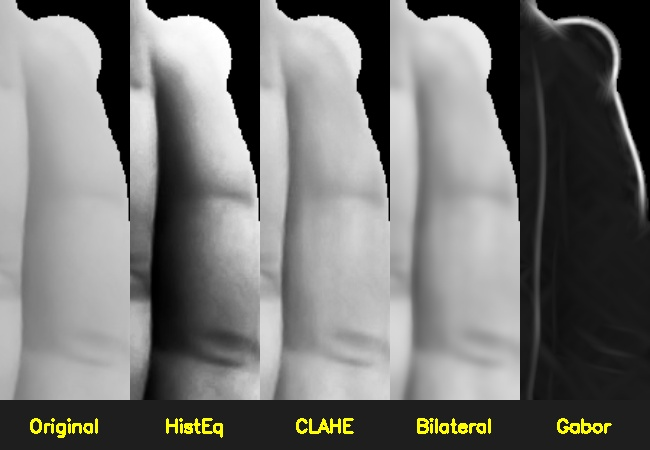

Enhancement Stages - Sample 4

## 5.3 Technical Details

```python
# CLAHE Configuration
clahe = cv2.createCLAHE(clipLimit=2.0, tileGridSize=(8, 8))

# Bilateral Filter
bilateral = cv2.bilateralFilter(img, d=9, sigmaColor=75, sigmaSpace=75)

# Gabor Filter Bank (16 orientations)
for theta in np.arange(0, np.pi, np.pi/16):
    kernel = cv2.getGaborKernel(ksize=(31,31), sigma=5.0,
                                 theta=theta, lambd=10.0, gamma=0.5)
    response = cv2.filter2D(img, cv2.CV_32F, kernel)
    accumulator = np.maximum(accumulator, response)
```

The **Gabor filter** is specifically designed for fingerprint ridge detection—it responds maximally to ridge-like structures at specific orientations.

# 6. Minutiae Extraction

Minutiae are the distinctive features used in fingerprint matching: **ridge endings** (where a ridge terminates) and **bifurcations** (where a ridge splits into two).

## 6.1 Crossing Number Method

For each skeleton pixel, we examine its 8-connected neighbors and compute the crossing number:

$$CN = \frac{1}{2} \sum_{i=1}^{8} |P_i -
P_{i+1}|$$

where *P*<sub>9</sub> = *P*<sub>1</sub> (circular).

| CN Value | Interpretation |
| --- | --- |
| 1 | Ridge Ending |
| 2 | Normal ridge point |
| 3 | Bifurcation |

## 6.2 Minutiae Results

### Sample 0 - Minutiae Detection

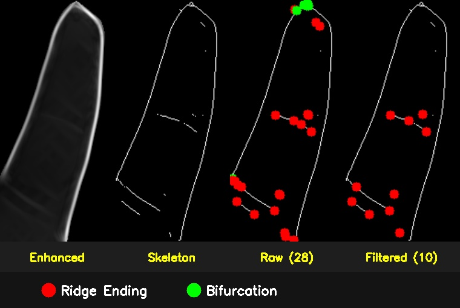

Minutiae: Enhanced → Skeleton → Raw Minutiae → Filtered (Red = Ending, Green = Bifurcation)

### Sample 2 - Minutiae Detection

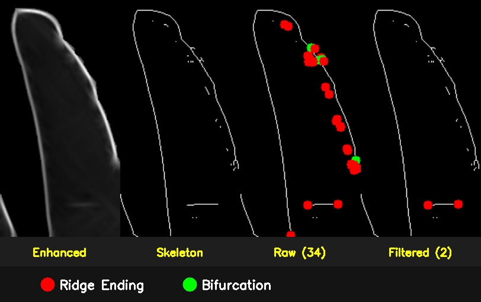

Minutiae Detection - Sample 2

### Sample 4 - Minutiae Detection

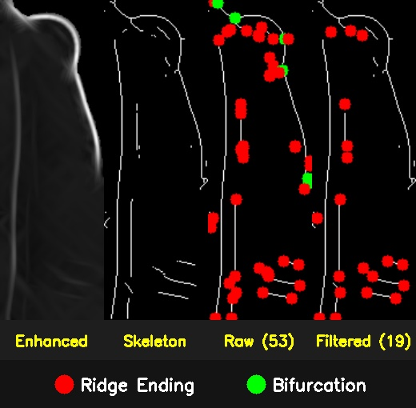

Minutiae Detection - Sample 4

## 6.3 Filtering Strategy

To reduce false minutiae, we apply several filters:

| Filter | Purpose | Threshold |
| --- | --- | --- |
| **Border Distance** | Remove minutiae near mask edges | ≥ 15px from border |
| **Cluster Removal** | Remove adjacent minutiae | ≥ 10px apart |
| **Count Limit** | Keep most reliable points | Max 50 minutiae |

# 7. Summary of Results

## 7.1 Best Configuration

Based on our experiments, the optimal pipeline configuration is:

| Stage | Method | Parameters |
| --- | --- | --- |
| **Detection** | MediaPipe Hand Landmarker | num_hands=2, confidence=0.5 |
| **Segmentation** | GrabCut + Edge Refinement | 8 iterations, 30px markers |
| **Enhancement** | CLAHE + Bilateral + Gabor | clipLimit=2.0, 16 orientations |
| **Extraction** | Crossing Number | Border distance ≥ 15px |

## 7.2 Performance Comparison

[output not shown]

## 7.3 Minutiae Quality

[output not shown]

# 8. Conclusions

## 8.2 Limitations

- **Image quality dependency**: Results degrade significantly with low-resolution or blurry images
- **Lighting sensitivity**: Extreme lighting conditions affect ridge visibility
- **Computational cost**: GrabCut is relatively slow (~200ms per image)

## 8.3 Future Work

- Implement deep learning-based segmentation (e.g., U-Net) for faster, more robust results
- Add orientation field estimation for improved Gabor filtering
- Develop quality scoring to reject poor-quality fingerprint regions
- Integrate with fingerprint matching algorithms for end-to-end verification

# 9. Appendix: Implementation Details

## 9.1 Dependencies

```
opencv-python>=4.5.0
numpy>=1.21.0
scikit-image>=0.18.0
scipy>=1.7.0
mediapipe>=0.10.0
```

## 9.2 Key Files

| File | Purpose |
| --- | --- |
| `process_improved.py` | Main pipeline with dual segmentation comparison |
| `grabcut_tuning.py` | Parameter tuning experiments |
| `generate_report_v3.py` | Report image generation |

## 9.3 Hardware

- **Device**: Apple MacBook Pro (M1 Max)
- **Camera**: Standard smartphone camera (1080p)
- **Processing Time**: ~500ms per image (full pipeline)